```python
%%javascript
$.getScript('https://kmahelona.github.io/ipython_notebook_goodies/ipython_notebook_toc.js')
```

Below, we'll cover some basic **probability theory** and **statistics**. Much of machine learning is statistics-based, and so certain well-known classsifiers/regressors (such as naive Bayes) require some knowledge of probability theory. Also, we need to know something about statistical tests in order to evaluate the models we create.

Many of the examples will utilize the [SciPy](https://www.scipy.org/), which is a collection of math- and science-related libraries.

# Probability Distributions

For arbitrary sets of numerical values, the mean, median, standard-deviation, etc., are easy to understand and compute, provided the sets are finite. When dealing with infinite sets, things are a bit less intuitive, but these concepts still make sense.

Consider an infinite sequence of rolls of a 6-sided die (suppose the die is not fair, so that 4 comes up more often). A *sample* is a (potentially infinite) subset of that sequence, e.g., $6, 3, 5, 1, 2, 2, 4, 5, 6, \ldots$. Alternatively, consider taking measurements of a physical, real-valued phenomenon. We can only collect a finite sample of measurements, but in theory at least there are an infinite number of measurements we could make. In such cases, we talk about *random variables*, *expected values*, and *probability distributions*.

## Random Variables and Probability Distributions

A **random variable** is a variable whose value is subject to chance.

- **Discrete random variables** take values from a finite or countably infinite set.
- **Continuous random variables** take values from some real-valued interval.

The set of possible values is called the *sample space*, symbolized $S$, $\Omega$, or $U$. Below, we'll use $S$.

- A single item from $S$ is called an **outcome**.
- A subset of $S$ is called an **event**.

Example:

- Let $S = \{1,2,3,4,5,6\}$.
- Event 1 = $\{2,4,6\}$ (rolling an even number)
- Event 2 = $\{1,5\}$ (rolling a 1 or a 5)

The **probability** of an event is the proportion of times that the event would occur based on a repeated random sampling of the variable. E.g., the probability that a 1 is rolled ($Pr(X = 1)$) is 1/6th, while the probability of rolling a 5 or less ($Pr(X \leq 5)$) is 5/6th.

A **probability distribution** for random variable $X$ is a function from values of $X$, or a range of values of $X$, to the interval $[0,1]$. There are an infinite number of possible distributions. In a **uniform** distribution, each outcome is equally likely. Rolls of a fair die are uniformly distributed, while those of a die that favors one side are not.

If $X$ is **discrete**, a **probability mass function (pmf)** $f$ is used to describe the distribution: $f$ is any function such that for each $e\in S$,

- $0 \leq f(e) \leq 1$, and
- $\displaystyle\sum_{e\in S} f(e) = 1$

In the discrete case, $f(e)$ is the probability that $X$ takes value $e$. That is, $f(e)$ is $Pr(X = e)$.

If $X$ is instead **continuous**, a **probability density function** (described below) is used.

## Expected Value (Mean) and Variance of Discrete Distributions

For a discrete random variable $X$, the **average**, **mean**, or **expected value** $\mu$ (or $E[X]$) is defined as follows:

$\mu =\displaystyle\sum_{e \in X}e\times Pr(e)$

As we continue to roll a fair 6-sided die, the mean value of the growing sample (a finite set) will converge to $\mu$.

$1*1/6 + 2*1/6 + 3*1/6 + 4*1/6 + 5*1/6 + 6*1/6 = 21/6= 3.5$

The **variance** $\sigma^2$ for a discrete random variable is:

$\sigma^{2} =\displaystyle\sum_{e\in X}(e - \mu)^{2}Pr(e) = E[(X - \mu)^{2}]$

For a fair die:

$\sigma^{2} = (1-3.5)^{2}*\frac{1}{6} + (2-3.5)^{2}*\frac{1}{6} + (3-3.5)^{2}*\frac{1}{6} + (4-3.5)^{2}*\frac{1}{6} + (5-3.5)^{2}*\frac{1}{6} + (6-3.5)^{2}*\frac{1}{6}$

$\sigma^{2} = \frac{1}{6}[(-2.5)^{2}+ (-1.5)^{2} + (-0.5)^{2} + (0.5)^{2} + (1.5)^{2} + (2.5)^{2}]$

$\sigma^{2} = \frac{1}{6}\times 17.5 \approx2.916667$

The **standard deviation**, $\sigma$, is the square-root of the variance.

The SciPy library allows us to work with uniform distributions. With `scipy.stats.randint`, we can use `rvs` generate uniformly distributed integer values.

```python
import numpy as np
from scipy.stats import randint

#generate a sample of integers, uniformly taken from 1 to 6.
data = randint.rvs(1, 7, size=10000) # min is loc and max is scale-1

# print out the mean value of the sample.
print("Method 1")
print("Mean: ", data.mean())
print("Variance: ", data.var(ddof=1))


# Alternatively...
x = randint(1,7)
data = np.empty(10000);
for i in range(10000):
    data[i]=x.rvs()

print("\nMethod 2")
print("Mean: ", np.mean(data))
print("Variance: ", np.var(data,ddof=1))
```

```
Method 1
Mean:  3.4865
Variance:  2.9425120012001207

Method 2
Mean:  3.5005
Variance:  2.935893339333933
```

## Cumulative Distribution Functions

If $X$ is numeric, a **cumulative distribution function** **cdf** can be defined based on the probability mass function.

$cdf(a) =\displaystyle\sum_{x\leq a}Pr(x)$

$cdf(a)$ computes the probability that a arbitrarily selected value from $X$ is $\leq a$. We can write this $Pr(X≤a)$. Observe that this is a monotone non-decreasing function.

In SciPy, `cdf` can be used to calculate $Pr(X \leq a)$ for a given $a$.

```python
x = randint(1,7)
v = [1,2,3,4,5,6]
for i in v:
    print(i,":", x.cdf(i))

import matplotlib.pyplot as plt
plt.bar(v,x.cdf(v))
pass
```

[output not shown]

```
1 : 0.16666666666666666
2 : 0.3333333333333333
3 : 0.5
4 : 0.6666666666666666
5 : 0.8333333333333334
6 : 1.0
```

The inverse of `cdf` is `ppf`, for **percent point function**.

```python
x = randint(1,7)
p = [0.5,1.0]
for i in p:
    print(i, ":", x.ppf(i))
```

```
0.5 : 3.0
1.0 : 6.0
```

## Probability Density Functions

For **continuous random variables**, the probability of a single outcome is 0, and so we don't use a probability mass function as the distribution. Instead we use a **probability density function** $f$.

The function $f$ is typically defined over the real numbers $\mathbf{R}$; it should have the following properties.

- For each $x\in \mathbf{R}$, $f(x) \geq 0$.
- $\displaystyle\int_{-\infty}^{\infty} f(x)dx = 1$. That is, the area under the curve must be 1.

The probability that $X$ is between $a$ and $b$ is defined as: $Pr(a\leq x \leq b) = \displaystyle\int_{a}^{b} f(x)dx$

For a continuous random variable $X$, the mean is:

$\displaystyle\int_{-\infty}^{\infty} x f(x)dx$.

The variance of a continuous random variable is:

$ \sigma^{2} = \displaystyle\int_{-\infty}^{\infty} (x-\mu)^{2}f(x)dx = E[(X - \mu)^{2}]$

Finally, the cumulative distribution function based on the pdf $f$ is:

$ cdf(b) = Pr(X\leq b) = \displaystyle\int_{-\infty}^{b} f(x)dx$

Again, this is a monotone non-decreasing function.

In SciPy, we can use `rvs` from `scipy.stats.uniform` to generate uniformly distributed floating point values.

- https://docs.scipy.org/doc/scipy/reference/generated/scipy.stats.uniform.html
- https://docs.scipy.org/doc/scipy/reference/generated/scipy.stats.rv_continuous.html

We can generate a specific sample and calculate statistics for it, or we can create a uniform random variable with specified min and max values and call methods to retrieve parameter values for it.

```python
import numpy as np
from scipy.stats import uniform

#generate a sample of floating point values, uniformly taken from 0 to 100.
data = uniform.rvs(loc=0, scale=100, size=100000) # min is loc and max is (loc+scale)

# print out the mean value of the sample.
print("Mean: ", data.mean())
print("Variance: ", data.var(ddof=1))

f = uniform(0,100)
print("f Mean: ", f.mean())
print("f Variance: ", f.var())

data = f.rvs(100000)
print("Sample Mean: ", data.mean())
print("Sample Variance: ", data.var(ddof=1))
```

```
Mean:  49.99988628450406
Variance:  836.3306612355715
f Mean:  50.0
f Variance:  833.3333333333333
Sample Mean:  49.962216616381006
Sample Variance:  836.1521698282296
```

`uniform.rvs()` without any arguments will only generae 1 value.

```python
print(uniform.rvs()) # print 1 float in range 0 to 1.
print(uniform.rvs(size=10)) # print 10 floats in range 0 to 1.
```

```
0.809619725388224
[0.44369037 0.17390608 0.91430108 0.74668381 0.79741257 0.73585069
 0.19888654 0.98830973 0.8766972  0.17732464]
```

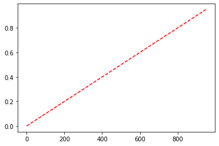

```python
f = uniform(0,1000)
x = range(0,1000,50)
import matplotlib.pyplot as plt
plt.plot(x, f.cdf(x), 'r--')
```

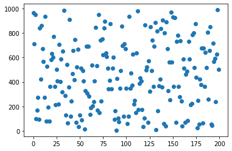

```python
x = range(200)
y = f.rvs(200)
plt.scatter(x, y)
```

## Normal Distributions

Of special note are so-called **normal distributions** $N(\mu,\sigma)$, defined by probability distribution functions having the below form, where $\mu$ is the mean, and $\sigma$ is the standard deviation.

$f(x) = \frac{1}{\sigma\sqrt{2\pi}} 𝑒^{−\frac{(x-\mu)^{2}}{2\sigma^{2}}}$

Each function will generate a symmetric, bell-shaped curve. The **standard normal distribution** has $\mu =0$ and $\sigma = 1$.

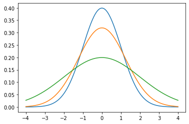

```python
import matplotlib
import matplotlib.pyplot as plt
import math

def y(x, mu=0, sigma=1):
    return 1/(sigma*math.sqrt(2*math.pi))*math.e**(-1*((x-mu)*(x-mu))/(2*sigma*sigma))
x = np.linspace(-4,4,200)

plt.plot(x,y(x))
plt.plot(x,y(x,0,1.25))
plt.plot(x,y(x,0,2))
pass
```

In SciPy, we can use `norm` from `scipy.stats` to create normal distributions (normally distributed variables). The attributes `loc` and `scale` are used to set the mean and standard deviation, respectively. To access the probability density function and apply it to an array of values `x`, we use `norm.pdf(x)`.

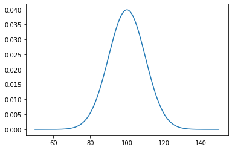

```python
from scipy.stats import norm

x = np.linspace(50, 150, 1000) # generate 1000 points between 50 and 150, equally separated.
y = norm(loc=100, scale=10) # create a normal distribution with mu=100 and std=10
plt.plot(x, y.pdf(x), '-') # plot x vs pdf of x.
pass
```

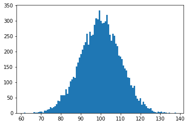

```python
f = norm(loc=100, scale=10)
data = f.rvs(10000)
plt.hist(data, bins=100)
pass
```

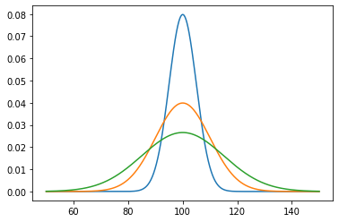

```python
x = np.linspace(50, 150, 1000) # generate 1000 points between 50 and 150, equally separated.
y1 = norm(loc=100, scale=5) # create a normal distribution with mu=100 and std=5
y2 = norm(loc=100, scale=10) # create a normal distribution with mu=100 and std=10
y3 = norm(loc=100, scale=15) # create a normal distribution with mu=100 and std=15

plt.plot(x, y1.pdf(x), '-') # plot x vs pdf of x.
plt.plot(x, y2.pdf(x), '-') # plot x vs pdf of x.
plt.plot(x, y3.pdf(x), '-') # plot x vs pdf of x.
pass
```

```python
print( norm.rvs(loc=100,scale = 10, size = 10))
```

```
[ 93.66096754  96.1054436  106.86125324 103.38106683  77.69560484
  83.80985337 111.62402474  73.74086057  89.44667383  83.59903754]
```

As with uniform distributions, we can calculate cummulative probabilities using `cdf`.

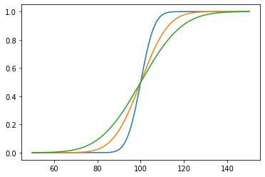

```python
plt.plot(x, y1.cdf(x), '-') # plot x vs cdf of x.
plt.plot(x, y2.cdf(x), '-') # plot x vs cdf of x.
plt.plot(x, y3.cdf(x), '-') # plot x vs cdf of x.
pass
```

## The Empirical Rule

If $X$ is normally distributed, then the following all hold.

- $Pr(\mu-1\sigma \leq x \leq \mu+1\sigma) \approx 68\%$
- $Pr(\mu-1.65\sigma \leq x \leq \mu+1.65\sigma) \approx 90\%$
- $Pr(\mu-1.96\sigma \leq x \leq \mu+1.96\sigma) \approx 95\%$
- $Pr(\mu-3\sigma \leq x \leq \mu+3\sigma) \approx 100\%$

In other words, roughly 95% of values are within 2 standard deviations of the mean.

## Standard Scores

For the standard normal distribution, the values of the random variable are called **standard scores** or **z-scores**. They indicate number of standard deviations from the mean.

Historically, we would look up the cummulative probability of a given z-score using a **standard normal table** (https://en.wikipedia.org/wiki/Standard_normal_table). Now we can just use software. In Python, given a `norm` object, we can calculate probabilities of a given z-score using `cdf`.

```
Pr(x <=  -4 ) = 3.167124183311986e-05
Pr(x <=  -3.5 ) = 0.00023262907903552502
Pr(x <=  -3 ) = 0.0013498980316300933
Pr(x <=  -2.5 ) = 0.006209665325776132
Pr(x <=  -2 ) = 0.022750131948179195
Pr(x <=  -1.5 ) = 0.06680720126885807
Pr(x <=  -1 ) = 0.15865525393145707
Pr(x <=  -0.5 ) = 0.3085375387259869
Pr(x <=  0 ) = 0.5
Pr(x <=  0.5 ) = 0.6914624612740131
Pr(x <=  1 ) = 0.8413447460685429
Pr(x <=  1.5 ) = 0.9331927987311419
Pr(x <=  2 ) = 0.9772498680518208
Pr(x <=  2.5 ) = 0.9937903346742238
Pr(x <=  3 ) = 0.9986501019683699
Pr(x <=  3.5 ) = 0.9997673709209645
Pr(x <=  4 ) = 0.9999683287581669
```

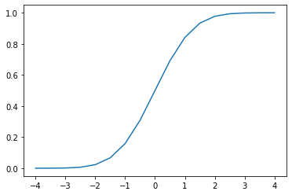

```python
dist = norm(0,1)
x = [-4,-3.5, -3, -2.5, -2, -1.5,-1,-0.5,0,0.5,1,1.5,2,2.5,3,3.5,4]
for i in x:
    print("Pr(x <= ",i,") =", dist.cdf(i))
plt.plot(x,dist.cdf(x))
pass
```

Regarding standard normal tables, there are a few common varieties, and so one must understand the formatting before they can be successfully used.

https://en.wikipedia.org/wiki/Standard_normal_table#Cumulative

Sometimes, only one side of the curve appears in the table. Since the curve is symmetrical, however, it's easy to calculate values for the other half.

```python
dist = norm(0,1)
print(dist.cdf(2))
print(dist.cdf(-2))
val = 1 - dist.cdf(2)
print(val)
```

```
0.9772498680518208
0.022750131948179195
0.02275013194817921
```

**Standardization**

For a normal distribution with $\mu \neq 0$ and/or $\sigma \neq 1$, we can convert values of the random variable to a corresponding z-score. Recall, $z$ denotes the number of standard deviations from the mean. So, given an $x$ taken from $N(\mu,\sigma)$, the distance between $x$ and $\mu$ is given by $x-\mu = z\sigma$. Solving for $z$ yields

$𝑧= \frac{(𝑥−\mu)}{\sigma}$

So, if we know $\mu$ and $\sigma$, to compute a z-score for $x$, we subtract $\mu$ from $x$ and then divide by $\sigma$

**Example:**

Given distribution $N(\mu=3.14,\sigma=2.5)$, what is $Pr(x \leq 4)$?

Using the above equation, we find the z-score for $x=4$.

$z = (4-3.14)/2.5 = 0.344$

```python
dist = norm(loc=3.14, scale=2.5)
import scipy.stats
print(dist.cdf(4))
```

```
0.6345768569541262
```

## The Central Limit Theorem

Suppose some population $P$ has mean $\mu$ and standard deviation $\sigma$. Now consider the set of random samples taken from $P$, each with size $n$. Each sample has a measurable mean and standard deviation.

Given the above, the following all hold.

- **The means of the samples will be approximately normally distributed.**
- **The mean of the sample means is $\mu$ (the mean of $P$).**
- **The standard deviation of the sample means is $\frac{\sigma}{\sqrt{n}}$**.

Note that the original population $P$ need not be normally distributed.

The term $\frac{\sigma}{\sqrt{n}}$ is called the **standard error** (of the mean, sometimes written SEM). Note that as the standard deviation of the sample means, it is a measure of dispersion.

Given that $n$ is in the denominator, as $n$ gets bigger, $\frac{\sigma}{\sqrt{n}}$ gets smaller. That is, as the sample size grows larger, the narrower the distribution of sample means will be.

## Testing the Theorem

We can run tests to help convince us that the Central Limit Theorem is true. Below, we create a function that accepts a population and a sample size and then generates multiple samples of the given size. The mean and standard deviation of the sample means is then calculated.

We'll use the function to test what happens as we change the sample size.

```python
import numpy as np
import matplotlib
import matplotlib.pyplot as plt

def clt_test (sample_size, pop, iterations=1000):
    sample_means = np.empty(iterations);
    pos = 0;
    for it in range(iterations):
        s = np.random.choice(pop, size=sample_size, replace=False)
        sample_means[pos] = np.mean(s)
        pos += 1

    mean_sample_means = np.mean(sample_means)
    sd_sample_means = np.std(sample_means)
    return sample_means

def write_results (sample_size, pop, sample_means):
    pop_mean = np.mean(pop)
    pop_sd = np.std(pop)
    standard_error = pop_sd/np.sqrt(sample_size)
    mean_sample_means = np.mean(sample_means)
    sd_sample_means = np.std(sample_means)
    print("population mean: ", pop_mean)
    print("population sd: ", pop_sd)
    print("standard_error: ", standard_error)
    print("mean of sample means: ", np.mean(sample_means))
    print("sd of sample means: ", sd_sample_means)
```

```
min:  0.0004891820000760827
max:  0.9999693657279288
mean:  0.5012258395761136
sd:  0.28885010514133447
```

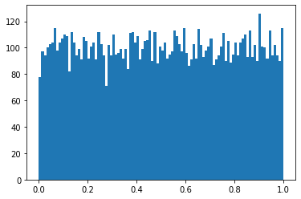

```python
pop = np.random.rand(10000)
plt.hist(pop, 100)
print("min: ", np.min(pop))
print("max: ", np.max(pop))
print("mean: ", np.mean(pop))
print("sd: ", np.std(pop))
pass
```

### Sample size n=5

```
population mean:  0.5012258395761136
population sd:  0.28885010514133447
standard_error:  0.12917769408079707
mean of sample means:  0.5034950521793676
sd of sample means:  0.13273451003345463
```

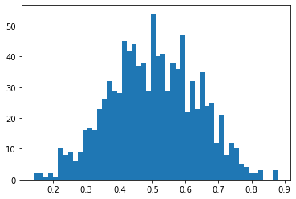

```python
sample_size = 5
bins = 50
result = clt_test(sample_size,pop)
write_results(sample_size, pop, result)
plt.hist(result, bins)
pass
```

### Sample size n=10

```
population mean:  0.5012258395761136
population sd:  0.28885010514133447
standard_error:  0.09134242346257294
mean of sample means:  0.5032518267044469
sd of sample means:  0.08821070243098893
```

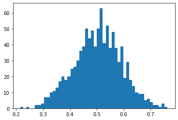

```python
sample_size = 10
bins = 50
result = clt_test(sample_size,pop)
write_results(sample_size, pop, result)
plt.hist(result, bins)
pass
```

### Sample size n=30

```
population mean:  0.5012258395761136
population sd:  0.28885010514133447
standard_error:  0.05273657277454928
mean of sample means:  0.5005891457861625
sd of sample means:  0.051935462103719895
```

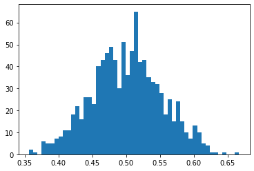

```python
sample_size = 30
bins = 50
result = clt_test(sample_size,pop)
write_results(sample_size, pop, result)
plt.hist(result, bins)
pass
```

### Sample size n=100

```
population mean:  0.5012258395761136
population sd:  0.28885010514133447
standard_error:  0.028885010514133447
mean of sample means:  0.5009698628247701
sd of sample means:  0.02679529020634919
```

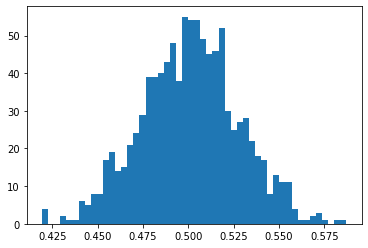

```python
sample_size = 100
bins = 50
result = clt_test(sample_size,pop)
write_results(sample_size, pop, result)
plt.hist(result, bins)
pass
```

### Sample size n=1000

```
population mean:  0.5012258395761136
population sd:  0.28885010514133447
standard_error:  0.009134242346257296
mean of sample means:  0.5013157846444238
sd of sample means:  0.0086282195569991
```

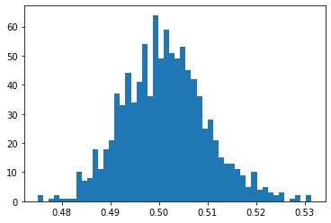

```python
sample_size = 1000
bins = 50
result = clt_test(sample_size,pop)
write_results(sample_size, pop, result)
plt.hist(result, bins)
pass
```

### Sample size n=5000

```
population mean:  0.5012258395761136
population sd:  0.28885010514133447
standard_error:  0.004084957361837696
mean of sample means:  0.5011830338436871
sd of sample means:  0.0029938528113432387
```

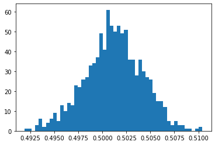

```python
sample_size = 5000
bins = 50
result = clt_test(sample_size,pop)
write_results(sample_size, pop, result)
plt.hist(result, bins)
pass
```

Below, we plot the standard deviation of the sample means as we increase the sample size (from 2 to 1000).

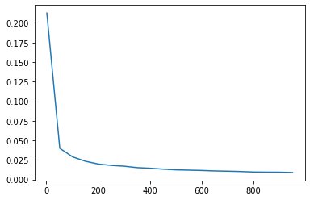

```python
max_sample_size = 1000
stepsize = 50;
range_vals = range(2,max_sample_size,stepsize);
sd_array=np.empty(len(range_vals))
for i in range(len(range_vals)):
    sample_size = range_vals[i]
    sample_means = clt_test(sample_size,pop)
    sd_array[i] = np.std(sample_means)
    #np.append(sd_array,np.std(sample_means))

#print(np.array(range_vals).shape)
#print(sd_array.shape)
plt.plot(np.array(range_vals),sd_array)
pass
```

## A Preview of Confidence Intervals

As the sample size increases, the standard deviation of the sample means (i.e., the standard error) gets smaller (the sample means won't be very spread out).

Suppose we use a large sample size $n$. Because of this, the mean of a randomly selected sample will very likely be close to the other sample means and also to the true population mean $\mu$. More precisely, if we know the standard error $\frac{\sigma}{\sqrt{n}}$, since the distribution of means is approximately normally distributed with mean $\mu$ and standard deviation $\frac{\sigma}{\sqrt{n}}$, we can calculate for any sample $s_i$ the probability that $\mu$ (the actual population mean) is within a desired range.

Recall that for any normal distributed $P$ with mean $\mu_P$ and standard deviation $\sigma_P$, $Pr(\mu_P-1.65\sigma_P \leq x \leq \mu_P+1.65\sigma_P) \approx 90\%$.

When speaking of the means of samples, we use $\frac{\sigma}{\sqrt{n}}$ as the standard deviation. So, if $m$ is the mean of a sample, then 90% of the time, $\mu$ is $m \pm 1.65 \frac{\sigma}{\sqrt{n}}$.

- 90% of the time, $m$ is $\leq 1.65 \frac{\sigma}{\sqrt{n}}$ units away from $\mu$.
- 90% of the time, $\mu$ is $\leq 1.65 \frac{\sigma}{\sqrt{n}}$ units away from $m$.
- 90% of the time, $\mu$ is $\leq m \pm 1.65 \frac{\sigma}{\sqrt{n}}$.

That is, if we knew $\frac{\sigma}{\sqrt{n}}$, then given a particular sample, we could calculate a **confidence interval** for the true mean of the population. Above, we've calculated the 90% confidence interval, but other levels could be used.

However, note that calculating the confidence interval requires knowing $\sigma$, the true population standard deviation. We typically don't know that any more than we know the true population mean $\mu$. Because of this, in order to calculate confidence intervals, the *sample standard deviation* is used as a substitute, and also another distribution (a t-distribution rather than a normal distribution) is assumed.

This is covered in another section.